# Deep Learning-Based Load Characterization and Deformation Prediction for Bio-Sourced Onion Peel Piezoelectric Sensors

**Author:** Aryan Senthil  
**Institution:** University of Oklahoma  
**Principal Investigator:** Dr. Mrinal Saha

[View on GitHub](https://github.com/AryanSenthil/Onion_Sensor)

## Abstract

This work presents the development of a self-powered pressure sensor utilizing onion peel waste as the active piezoelectric material, combined with machine learning techniques to enable intelligent deformation sensing. Agricultural waste in the form of dehydrated and ground onion peel was dispersed in a silicone matrix and fabricated via direct ink writing (DIW) 3D printing, where the self-aligned cellulose fibers generate voltage under mechanical stress. The sensor was characterized under cyclic compression at multiple deformation levels and load types.

To interpret the sensor's electrical response and extract deformation information, we developed a two-stage machine learning pipeline. Convolutional neural networks (CNNs) operating on Short-Time Fourier Transform (STFT) spectrograms classify the loading configuration, while a Wide & Deep regression model predicts deformation magnitude by fusing the load type with voltage signal features. This ML-enabled approach allows the bio-composite sensor to predict both the type and magnitude of applied pressure without the requirement of an external battery source unlike traditional pressure sensors.

The results demonstrate that combining sustainable materials with intelligent signal processing creates viable sensing platforms for applications in structural health monitoring, wearable electronics, and human-machine interfaces. By transforming agricultural waste into functional sensors augmented with machine learning, this work opens pathways for environmentally conscious sensor technologies with embedded intelligence.

#### Disclaimer

*This research work and all associated materials are the property of the University of Oklahoma and were conducted under the supervision of Dr. Mrinal Saha. All rights reserved. This work is part of ongoing research and may not be reproduced, distributed, or used for commercial purposes without prior written permission from the University of Oklahoma.*

## 1. Piezoelectricity and Piezoelectric Effect

**Piezoelectricity** is the linear electromechanical coupling between mechanical and electrical domains.  
**Piezoelectric effect** refers to an electric polarization induced by an applied mechanical stress (σ).

### 1.1 Mathematical Expression

$$ P_i = d_{ijk} \, \sigma_{jk} $$

**where:** $P_i$ = Electric polarization, $d_{ijk}$ = Piezoelectric coefficient tensor, $\sigma_{jk}$ = Applied mechanical stress

### 1.2 Why Piezoelectric Materials?

For **piezoelectric materials**, the crystal's structure is **asymmetrical**. When no external force is applied, the crystal is in a stable state and doesn't display electrical polarity to the outside. However, when an external force is applied, the crystal's atoms disperse and the internal charge distribution shifts, creating **electrical polarity** as the balance is disrupted.

[figure not shown]

**Demonstration of piezoelectric effect:** *mechanical stress generates electrical charge*

## 2. Fabrication of Onion Peel-Based Piezoelectric Sensor

### 2.1 Material Selection and Rationale

In this research, we explored **onion peel** as a sustainable piezoelectric material due to its self-aligned cellulose fibers that exhibit polarization under applied mechanical stress. This approach transforms agricultural waste into a functional sensing material.

### 2.2 Material Preparation Protocol

1. **Collection and Dehydration**: Onion peel waste material was collected and thoroughly dehydrated
2. **Grinding**: Dehydrated peels were ground using a high-speed grinder (3600 rpm)
3. **Sieving**: Ground material was sieved using a vibrating sieve shaker to obtain uniform particle size distribution (roughly 25 $\,\mu\text{m}$)

### 2.3 Sensor Fabrication Process

**Step 1: Composite Ink Preparation**

- Onion peel powder was dispersed in a silicone matrix (Ecoflex 00-30, 1:1 base:curing agent ratio)
- The mixture was homogenized at 1500 rpm for 5 minutes to form an active composite ink

**Step 2: 3D Printing via Direct Ink Writing (DIW)**

- The composite ink was printed layer-by-layer using a pneumatic DIW printer
- Ink rheology was carefully tuned to ensure smooth extrusion and dimensional stability during printing

**Step 3: Electrode Application**

- Conductive electrodes were applied to both surfaces of the printed sensor using silver paste to establish electrical contacts

### 2.4 Characterization and Testing

The fabricated sensor was connected to an **electrometer** to measure voltage generation under mechanical loading. Two loading conditions were evaluated:

- **Point Load**: Localized force applied to a specific region of the sensor
- **Uniform Load**: Distributed force applied across the entire sensor surface

As expected, voltage output was successfully measured under both loading conditions, confirming the piezoelectric response of the onion peel-based sensor.

[figure not shown]

**Fabrication workflow:** *CAD design → 3D printing → assembled sensor → testing configuration*

[figure not shown]

**Load Test Configurations:** *(a) Point Load - force applied to a localized region of the sensor; (b) Uniform Load - force distributed across the entire sensor surface*

## 3. Experimental Data Collection

Piezoelectricity is a function of stress. The mechanical stress (σ) applied to the sensor is related to the deformation through Hooke's law:

$$\sigma = \mathbf{E} \cdot \frac{\mathbf{\Delta h}}{\mathbf{h_0}}$$

**where:** $\mathbf{E}$ = Young's modulus of the composite material, $\mathbf{\Delta h}$ = change in sensor height, $\mathbf{h_0}$ = original sensor height (2.64 mm)

**Experimental Approach:**  
The piezoelectric response of the onion peel-based sensor is characterized through **cyclic compression testing at three deformation levels** (Δh = 0.5, 0.7, and 1.0 mm) under **two distinct loading configurations** (point and uniform load), with continuous electrical measurements of **Voltage (V) Vs. Time (s)** captured throughout each loading cycle. The image below shows the compression-decompression cycle and the corresponding voltage generation over time.

[figure not shown]

**Piezoelectric Response:** *(Left) Load vs. displacement during cyclic compression; (Right) Voltage output over time showing peak generation during compression*

Testing Equipment: Instron tensile testing machine

Loading Condition: Cyclic compression-release at 100 mm/min

Sensor Geometry: Original height ($h_0$) = 2.64 mm

| Deformation Levels Δh (mm) | Deformation Levels Compression (% of Original Height) | Deformation Levels Stress Level |
| --- | --- | --- |
| 0.5 | 20% | Low |
| 0.7 | 30% | Medium |
| 1.0 | 40% | High |

### 3.1 Electrical Signal Acquisition

Measurement Equipment: Keithley 6517B electrometer

Data Acquisition: Continuous voltage-time recordings during cyclic loading

Sampling Configuration: Each dataset represents 1 minute of continuous cycling at 100 mm/min

[output not shown]

### 3.2 Dataset Organization and Structure

To facilitate systematic analysis, continuous voltage-time recordings were segmented into **10-second intervals**, with each interval representing one sample.

| Final Dataset Distribution Loading Type | Final Dataset Distribution 0.5 mm (20% compression) | Final Dataset Distribution 0.7 mm (30% compression) | Final Dataset Distribution 1.0 mm (40% compression) | Final Dataset Distribution Total Samples |
| --- | --- | --- | --- | --- |
| Point Load | 16 | 24 | 32 | 72 |
| Uniform Load | 16 | 24 | 32 | 72 |
| Total per Deformation | 32 | 48 | 64 | 144 |

# 4. Machine Learning Model Architecture for Load Characterization and Deformation Prediction

The piezoelectric response of our onion peel-based sensor exhibits distinct voltage-time signatures that correlate strongly with both the type of applied load (point vs. uniform) and the magnitude of deformation. We developed a novel **two-stage machine learning architecture** that leverages these correlations to simultaneously classify load type and predict deformation level from the sensor's electrical output.

## 4.1 Two-Stage Model Architecture

## 4.2 Load Classification Module

The cyclic mechanical loading produces characteristic voltage waveforms that vary distinctly between point and uniform load configurations. To classify these patterns, we treat the voltage-time data as audio signals and employ **convolutional neural networks (CNNs)** on their time-frequency representations.

### 4.2.1 Signal Processing Pipeline

**Data Segmentation:** Continuous voltage-time recordings are segmented into 10-second intervals, each saved as a WAV file  
**Time-Frequency Analysis:** We apply the Short-Time Fourier Transform (STFT) to generate spectrograms

### 4.2.2 Mathematical Expression

[output not shown]

### 4.2.3 Why STFT for Cyclic Loading Analysis?

**Non-stationary Signal Characteristics:** The voltage response during cyclic compression-decompression is inherently non-stationary, the frequency content changes as the sensor transitions between loading and unloading phases. STFT preserves temporal evolution, capturing how spectral components emerge and decay during each loading cycle.

**Cycle-Specific Features:** Point and uniform loads produce different stress distributions across the sensor, resulting in distinct harmonic patterns during compression. STFT reveals these time-localized frequency signatures. Point loads generate sharper transients with higher frequency components at the moment of contact, while uniform loads show more gradual spectral evolution.

**Temporal Resolution:** Our 10-second recording windows contain multiple compression cycles. STFT allows us to resolve individual cycles within this window, providing a detailed time-frequency map that the CNN can learn to associate with specific load types.

**Robustness to Phase Variations:** Since mechanical loading may not be perfectly synchronized across samples, STFT's sliding window approach provides translation-invariant features that are robust to slight timing variations in the compression cycles.

### 4.2.4 CNN Architecture

[figure not shown]

**Load Classification Architecture:** *CNN that classifies point or uniform load*

## 4.3 Deformation Prediction Module: Wide & Deep Regression

Initial experiments using only peak-to-peak voltage as a predictor for deformation showed promising results. However, incorporating the load type as an additional feature in traditional multi-layer perceptron architectures yielded minimal improvement, the categorical nature of the load type was being diluted during training.

We adapted the **[Wide & Deep architecture](https://arxiv.org/pdf/1606.07792)** (Cheng et al., 2016), originally developed for recommender systems. This architecture elegantly combines memorization and generalization.

### 4.3.1 Architecture Components

**Wide Component:** A linear model that directly connects the load type (categorical feature) to the output, preserving its discriminative power through memorization  
**Deep Component:** A deep neural network that processes the peak-to-peak voltage through multiple non-linear transformations, enabling generalization across the continuous deformation space

[figure not shown]

**Wide & Deep Regression Architecture:** *Combining wide component (right) with deep component (left) for deformation prediction*

This architecture leverages the complementary strengths of both features: the wide component maintains the strong correlation between load type and voltage response patterns, while the deep component captures the non-linear relationship between voltage amplitude and deformation magnitude.

## 4.4 Integration and Inference Pipeline

During inference, the system operates as follows:  
**1.** Input voltage-time data is processed through the CNN classifier, outputting load type probabilities  
**2.** The predicted load type (argmax of probabilities) is converted to binary representation  
**3.** Peak-to-peak voltage is extracted from the raw signal  
**4.** Both features feed into the Wide & Deep regression model for deformation prediction

**Note on Feature Representation:** While the CNN outputs a probability distribution over load types during inference, the regression model uses a discrete binary input (0 or 1) to maintain consistency with the training paradigm where ground truth labels were used.

## 4.5 Results

# Implementation

The following cells contain the executable code that implements the methodology described above.

## Setup and Configuration

```python
import pathlib
from pathlib import Path
import json
import numpy as np
import tensorflow as tf

import classification_module
import regression_module
from tensorflow import keras

%load_ext autoreload
%autoreload 2
```

```python
# Configuration
classification_model_name = "classification_model"
regression_model_name = "regression_model"

CSV_DIR = r"/home/ari/Documents/Onion_Sensor/data"
SAMPLING_RATE = 1600
VALIDATION_SPLIT = 0.2
LEARNING_RATE = 0.001
Classification_EPOCHS = 10
REGRESSION_EPOCHS = 300
PATIENCE = 2
SEED = 42
TEST_SPLIT = 0.1
```

## Classification Module Training

```python
# Step 1: Preprocess CSV files to WAV format for STFT analysis
classification_module.preprocess_csv_to_wav(
    csv_dir=CSV_DIR,
    model_name=classification_model_name,
    sampling_rate=SAMPLING_RATE
)
```

```python
# Step 2: Load and preprocess spectrograms
classification_module.load_and_preprocess_data(
    model_name=classification_model_name,
    validation_split=VALIDATION_SPLIT,
    seed=SEED
)
```

```
Found 144 files belonging to 2 classes.
Using 116 files for training.
Using 28 files for validation.
```

```
✓ Dataset metadata: /home/ari/Documents/Onion_Sensor/models/classification_model/metadata/dataset_info.json
✓ Dataset details:
 - Input shape: [124, 129, 1]
 - Number of labels: 2
 - Label names: ['point', 'uniform']
✓ Data preprocessing complete: 1.5s
```

```python
# Step 3: Build model
classification_module.build_and_compile_model(
    model_name=classification_model_name,
    learning_rate=LEARNING_RATE
)
```

```
Model: "sequential"
```

```
┏━━━━━━━━━━━━━━━━━━━━━━━━━━━━━━━━━┳━━━━━━━━━━━━━━━━━━━━━━━━┳━━━━━━━━━━━━━━━┓
┃ Layer (type)                    ┃ Output Shape           ┃       Param # ┃
┡━━━━━━━━━━━━━━━━━━━━━━━━━━━━━━━━━╇━━━━━━━━━━━━━━━━━━━━━━━━╇━━━━━━━━━━━━━━━┩
│ resizing (Resizing)             │ (None, 32, 32, 1)      │             0 │
├─────────────────────────────────┼────────────────────────┼───────────────┤
│ normalization (Normalization)   │ (None, 32, 32, 1)      │             3 │
├─────────────────────────────────┼────────────────────────┼───────────────┤
│ conv2d (Conv2D)                 │ (None, 30, 30, 32)     │           320 │
├─────────────────────────────────┼────────────────────────┼───────────────┤
│ conv2d_1 (Conv2D)               │ (None, 28, 28, 64)     │        18,496 │
├─────────────────────────────────┼────────────────────────┼───────────────┤
│ max_pooling2d (MaxPooling2D)    │ (None, 14, 14, 64)     │             0 │
├─────────────────────────────────┼────────────────────────┼───────────────┤
│ dropout (Dropout)               │ (None, 14, 14, 64)     │             0 │
├─────────────────────────────────┼────────────────────────┼───────────────┤
│ flatten (Flatten)               │ (None, 12544)          │             0 │
├─────────────────────────────────┼────────────────────────┼───────────────┤
│ dense (Dense)                   │ (None, 128)            │     1,605,760 │
├─────────────────────────────────┼────────────────────────┼───────────────┤
│ dropout_1 (Dropout)             │ (None, 128)            │             0 │
├─────────────────────────────────┼────────────────────────┼───────────────┤
│ dense_1 (Dense)                 │ (None, 2)              │           258 │
└─────────────────────────────────┴────────────────────────┴───────────────┘
```

```
 Total params: 1,624,837 (6.20 MB)
```

```
 Trainable params: 1,624,834 (6.20 MB)
```

```
 Non-trainable params: 3 (16.00 B)
```

```
✓ Model built: /home/ari/Documents/Onion_Sensor/models/classification_model/models/untrained/model.keras
✓ Model build complete: 0.8s
```

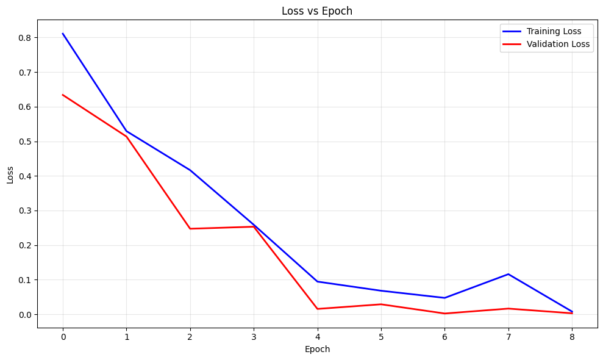

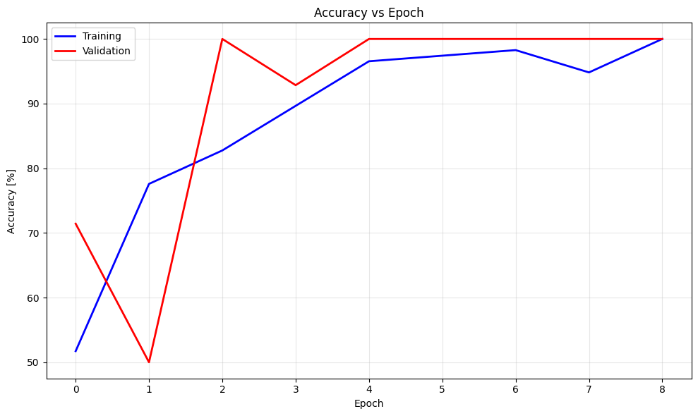

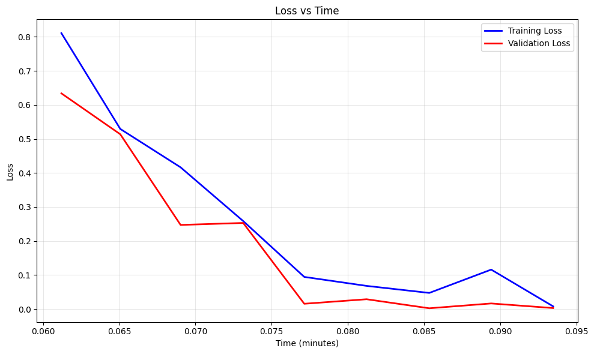

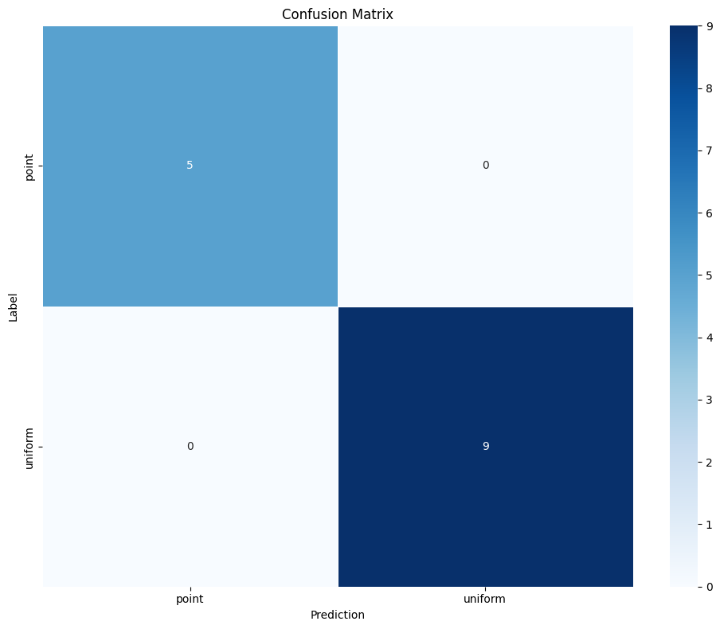

```
✓ Trained model: /home/ari/Documents/Onion_Sensor/models/classification_model/models/trained/model.keras
✓ Training plots: /home/ari/Documents/Onion_Sensor/models/classification_model/training/plots
✓ Training summary: /home/ari/Documents/Onion_Sensor/models/classification_model/training/training_summary.json
✓ Test accuracy: 100.0%
✓ Training complete: 9.1s
```

```python
# Step 4: Train CNN classification model
classification_module.train_and_evaluate_model(
    model_name=classification_model_name,
    epochs=Classification_EPOCHS,
    patience=PATIENCE
)
```

```python
# Step 5: Export trained classification model
classification_module.create_export_model(model_name=classification_model_name)
```

```
INFO:tensorflow:Assets written to: /home/ari/Documents/Onion_Sensor/models/classification_model/export/saved_model/assets
```

```
Assets written to: /home/ari/Documents/Onion_Sensor/models/classification_model/export/saved_model/assets
✓ Registry updated: /home/ari/Documents/Onion_Sensor/models.json
✓ Export model: /home/ari/Documents/Onion_Sensor/models/classification_model/export/saved_model
✓ Export complete: 1.0s
```

## Regression Module Training

```python
# Step 1: Preprocess regression data (extract peak-to-peak voltage and load types)
regression_module.preprocess_csv_data(
    csv_dir=CSV_DIR,
    model_name=regression_model_name,
    test_split=TEST_SPLIT,
    seed=SEED
)
```

```
OK Dataset metadata: /home/ari/Documents/Onion_Sensor/models/regression_model/metadata/dataset_info.json
OK Preprocessing complete: 7.5s
```

```python
# Step 2: Build model
regression_module.build_and_compile_model(
    model_name=regression_model_name,
    hidden_layers=[64, 64, 32, 16],
    learning_rate=LEARNING_RATE
)
```

```
Model: "functional_21"
```

```
┏━━━━━━━━━━━━━━━━━━━━━┳━━━━━━━━━━━━━━━━━━━┳━━━━━━━━━━━━┳━━━━━━━━━━━━━━━━━━━┓
┃ Layer (type)        ┃ Output Shape      ┃    Param # ┃ Connected to      ┃
┡━━━━━━━━━━━━━━━━━━━━━╇━━━━━━━━━━━━━━━━━━━╇━━━━━━━━━━━━╇━━━━━━━━━━━━━━━━━━━┩
│ deep_input          │ (None, 1)         │          0 │ -                 │
│ (InputLayer)        │                   │            │                   │
├─────────────────────┼───────────────────┼────────────┼───────────────────┤
│ deep_normalization  │ (None, 1)         │          3 │ deep_input[0][0]  │
│ (Normalization)     │                   │            │                   │
├─────────────────────┼───────────────────┼────────────┼───────────────────┤
│ deep_hidden_1       │ (None, 64)        │        128 │ deep_normalizati… │
│ (Dense)             │                   │            │                   │
├─────────────────────┼───────────────────┼────────────┼───────────────────┤
│ deep_hidden_2       │ (None, 64)        │      4,160 │ deep_hidden_1[0]… │
│ (Dense)             │                   │            │                   │
├─────────────────────┼───────────────────┼────────────┼───────────────────┤
│ wide_input          │ (None, 1)         │          0 │ -                 │
│ (InputLayer)        │                   │            │                   │
├─────────────────────┼───────────────────┼────────────┼───────────────────┤
│ deep_hidden_3       │ (None, 32)        │      2,080 │ deep_hidden_2[0]… │
│ (Dense)             │                   │            │                   │
├─────────────────────┼───────────────────┼────────────┼───────────────────┤
│ wide_normalization  │ (None, 1)         │          3 │ wide_input[0][0]  │
│ (Normalization)     │                   │            │                   │
├─────────────────────┼───────────────────┼────────────┼───────────────────┤
│ deep_hidden_4       │ (None, 16)        │        528 │ deep_hidden_3[0]… │
│ (Dense)             │                   │            │                   │
├─────────────────────┼───────────────────┼────────────┼───────────────────┤
│ wide_deep_concat    │ (None, 17)        │          0 │ wide_normalizati… │
│ (Concatenate)       │                   │            │ deep_hidden_4[0]… │
├─────────────────────┼───────────────────┼────────────┼───────────────────┤
│ output (Dense)      │ (None, 1)         │         18 │ wide_deep_concat… │
└─────────────────────┴───────────────────┴────────────┴───────────────────┘
```

```
 Total params: 6,920 (27.04 KB)
```

```
 Trainable params: 6,914 (27.01 KB)
```

```
 Non-trainable params: 6 (32.00 B)
```

```
OK Model built: /home/ari/Documents/Onion_Sensor/models/regression_model/models/untrained/model.keras
OK Model build complete: 0.1s
```

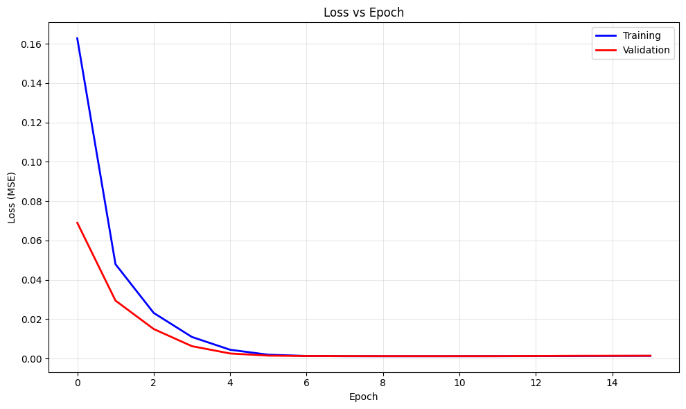

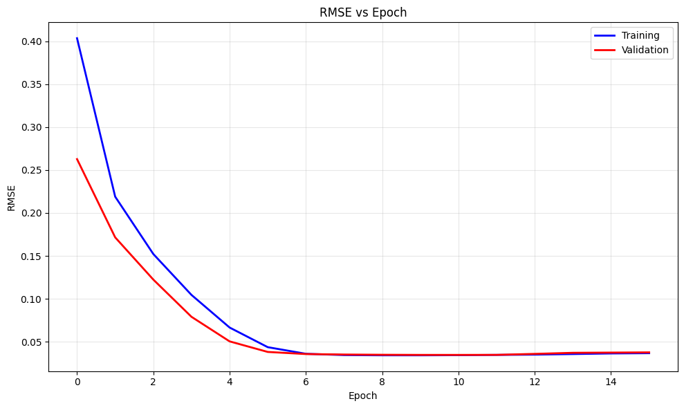

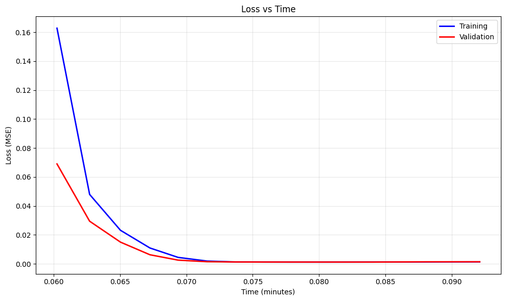

```
OK Trained model: /home/ari/Documents/Onion_Sensor/models/regression_model/models/trained/model.keras
OK Training plots: /home/ari/Documents/Onion_Sensor/models/regression_model/training/plots
OK Training summary: /home/ari/Documents/Onion_Sensor/models/regression_model/training/training_summary.json
OK Test RMSE: 0.040147
OK Training complete: 9.2s
```

```python
# Step 3: Train Wide & Deep regression model
regression_module.train_and_evaluate_model(
    model_name=regression_model_name,
    epochs=REGRESSION_EPOCHS,
    patience=5
)
```

```python
# Step 4: Export trained regression model
regression_module.create_export_model(model_name=regression_model_name)
```

```
INFO:tensorflow:Assets written to: /home/ari/Documents/Onion_Sensor/models/regression_model/export/saved_model/assets
```

```
Assets written to: /home/ari/Documents/Onion_Sensor/models/regression_model/export/saved_model/assets
OK Registry updated: /home/ari/Documents/Onion_Sensor/models.json
OK Export model: /home/ari/Documents/Onion_Sensor/models/regression_model/export/saved_model
OK Export complete: 0.6s
```

## Inference Pipeline

```python
# Load inference utilities and trained models
from test_model import WaveAnalysis, display_model_results

# Load trained models
classification_model = tf.saved_model.load(
    "/home/ari/Documents/Onion_Sensor/models/classification_model/export/saved_model"
)
regression_model = tf.keras.models.load_model(
    "/home/ari/Documents/Onion_Sensor/models/regression_model/models/trained/model.keras"
)
```

```python
# Run inference on test file
file_path = r"/home/ari/Documents/Onion_Sensor/test/test1.csv"

analysis = WaveAnalysis(classification_model, regression_model)
deformation, class_name = analysis.process_file_and_predict_deformation(file_path)

# Output the results
display_model_results(deformation, class_name, font_size=10)
```

```
1/1 ━━━━━━━━━━━━━━━━━━━━ 0s 398ms/step
```

```
╭──────────────────────────────────── MODEL PREDICTION RESULTS ────────────────────────────────────╮
│                                                                                                  │
│                                                                                                  │
│   ┏━━━━━━━━━━━━━━━━━━━━━━━━━━━━━━━━━━━━━━━━━━━━┳━━━━━━━━━━━━━━━━━━━━━━━━━━━━━━━━━━━━━━━━━━━━━┓   │
│   ┃                                            ┃                                             ┃   │
│   ┃                                            ┃                                             ┃   │
│   ┃    Metric                                  ┃                    Value                    ┃   │
│   ┃                                            ┃                                             ┃   │
│   ┃                                            ┃                                             ┃   │
│   ┡━━━━━━━━━━━━━━━━━━━━━━━━━━━━━━━━━━━━━━━━━━━━╇━━━━━━━━━━━━━━━━━━━━━━━━━━━━━━━━━━━━━━━━━━━━━┩   │
│   │                                            │                                             │   │
│   │                                            │                                             │   │
│   │    Predicted deformation                   │                  0.493 mm                   │   │
│   │                                            │                                             │   │
│   │                                            │                                             │   │
│   │                                            │                                             │   │
│   │                                            │                                             │   │
│   │    Type of load                            │                    point                    │   │
│   │                                            │                                             │   │
│   │                                            │                                             │   │
│   └────────────────────────────────────────────┴─────────────────────────────────────────────┘   │
│                                                                                                  │
│                                                                                                  │
╰──────────────────────────────────────────────────────────────────────────────────────────────────╯
```

## Design Philosophy: Agent-Tool Architecture

**Important Note for Code Reviewers and Lab Members:**

**The functions in this notebook are intentionally designed **not to return models, plots, or other objects** as variables. While this design choice may initially appear unconventional, it serves a deliberate architectural purpose aimed at maintaining modularity and system-level consistency. **This framework is currently being extended into an agentic interface that facilitates the training and evaluation of diverse datasets, providing an accessible environment for users without programming experience.****

### Why Functions Don't Return Values

These functions are specifically architected to serve as **tools for autonomous ML agents** that will be used by other lab members for training and testing on their own datasets. In an agent-based workflow:

1. **State Management**: All artifacts (trained models, generated plots, preprocessed data, evaluation metrics) are persisted to disk and managed through a directory-based state system rather than in-memory variables.
2. **Agent Memory**: The agent maintains its own state and memory by tracking file paths and metadata, not Python objects. This allows the agent to:
   - Resume workflows after interruptions
   - Share intermediate results across different execution contexts
   - Maintain a persistent record of all operations
3. **Tool Composition**: Each function acts as an independent, stateless tool that can be orchestrated by the agent. T"he agent decides when to call each tool based on the task requirements and maintains the overall workflow state.
4. **Multi-User Scenarios**: When multiple lab members deploy agents on different datasets, the directory-based approach ensures clear separation of artifacts and prevents memory conflicts.

### Why Functions Cannot Return Objects to Agents

**Agent tools are fundamentally different from traditional Python functions.**

When a human writes code interactively, they can capture return values:

```
model = train_model(data_path)
predictions = model.predict(X_test)
```

**Agents cannot do this.** When an agent calls a tool, the execution flow is:

1. Agent invokes: `train_model(data_path="/data/train.csv")`
2. Function executes and returns a value
3. **The returned value is immediately discarded** - agents have no Python runtime to store variables
4. Agent receives only a text confirmation (e.g., "Model training completed")

If a function returns a trained model object, that object vanishes the moment the function completes. The agent cannot assign it to a variable, cannot pass it to another function, and cannot inspect it. The return value is lost.

### The Solution: Disk-Based State Management

Since agents cannot maintain in-memory state through variable assignment, all artifacts must be persisted to disk:

```
def train_model(data_path, model_dir):
    """Agent-compatible tool function"""
    model = RandomForestClassifier()
    model.fit(X, y)

    # Save to disk - this is the ONLY way the agent can access it later
    joblib.dump(model, f"{model_dir}/model.pkl")

    # Return value is just a status message for the agent's log
    return f"Model trained and saved to {model_dir}/model.pkl"
```

The agent's workflow now relies on the filesystem as its working memory:

**Agent Internal State:**

```
{
  "trained_model_path": "/models/run_2024/model.pkl",
  "preprocessed_data": "/data/processed/features.csv",
  "evaluation_results": "/results/metrics.json"
}
```

When the agent needs to evaluate the model, it calls:

```
evaluate_model(model_path="/models/run_2024/model.pkl",
               test_data="/data/test.csv",
               output_dir="/results/")
```

The evaluation function loads the model from disk, processes it, and saves results back to disk. The agent never touches the Python objects directly, it only tracks file paths in its internal state. This helps with memory management, context window persistence and information retrieval when needed.

### Key Architectural Principles

1. **Functions are stateless tools**: Each function performs a discrete operation, reading inputs from disk and writing outputs to disk.
2. **Agent maintains execution context**: The agent's memory tracks file paths, execution history, and workflow state, not Python objects.
3. **Persistence over performance**: While loading/saving from disk is slower than in-memory operations, it enables workflow resumption, multi-session continuity, and multi-user isolation.
4. **Directory structure as API**: The organized directory layout (`/data/`, `/models/`, `/results/`) serves as the interface contract between tools.